# Insurance Data Analysis

## Insurance Data Analysis

### Objective:

To analyze the dataset that will help to create a model that will predict the cost of medical insurance based on various input features

### 1. Import libraries such as Pandas, matplotlib, NumPy, and seaborn and load the insurance dataset.

```python
import pandas as pd
import matplotlib.pyplot as plt
import numpy as np
import seaborn as sns
```

```python
df = pd.read_csv('insurance.csv')
```

```python
df.head()
```

|  | age | sex | bmi | children | smoker | region | charges |
| --- | --- | --- | --- | --- | --- | --- | --- |
| 0 | 19 | female | 27.900 | 0 | yes | southwest | 16884.92400 |
| 1 | 18 | male | 33.770 | 1 | no | southeast | 1725.55230 |
| 2 | 28 | male | 33.000 | 3 | no | southeast | 4449.46200 |
| 3 | 33 | male | 22.705 | 0 | no | northwest | 21984.47061 |
| 4 | 32 | male | 28.880 | 0 | no | northwest | 3866.85520 |

#### Observation:

- Successfully imported the required libraries and loaded the insurance dataset into a DataFrame named df.

### 2. Check the shape of the data along with the data types of the column

```python
shape=df.shape
print('shape of data',shape)
```

```
shape of data (1338, 7)
```

```python
data_type=df.dtypes
print(data_type)
```

```
age           int64
sex          object
bmi         float64
children      int64
smoker       object
region       object
charges     float64
dtype: object
```

#### Observation:

- The dataset has a specific number of rows and columns (1338, 7).
- The columns age, bmi, children, and charges are numerical.
- The columns sex, smoker, and region are categorical.

### 3. Check missing values in the dataset and find the appropriate measures to fill in the missing values

```python
df.isnull().sum()
```

```
age         0
sex         0
bmi         0
children    0
smoker      0
region      0
charges     0
dtype: int64
```

#### Observation:

- There are no missing values in any of the columns of the dataset.

### 4. Explore the relationship between the feature and target column using a count plot of categorical columns and a scatter plot of numerical columns

#### Count Plot of Smokers vs. Non-Smokers

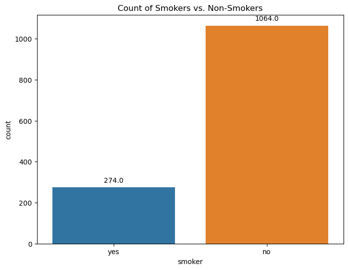

```python
plt.figure(figsize=(8, 6))
sns.countplot(x='smoker', data=df)
plt.title('Count of Smokers vs. Non-Smokers')

for p in plt.gca().patches:
    plt.gca().annotate(f'{p.get_height()}', (p.get_x() + p.get_width() / 2., p.get_height()),
                       ha='center', va='center', xytext=(0, 10), textcoords='offset points')
plt.show()
```

#### Scatter Plot of Age vs. Charges

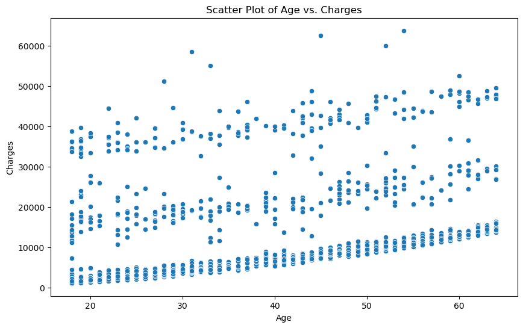

```python
plt.figure(figsize=(10, 6))
sns.scatterplot(x='age', y='charges', data=df)
plt.title('Scatter Plot of Age vs. Charges')
plt.xlabel('Age')
plt.ylabel('Charges')
plt.show()
```

#### Observation:

- The count plot shows the distribution of smokers and non-smokers.
- The scatter plot shows the relationship between age and charges, indicating that charges tend to increase with age.

## 5. Perform data visualization using plots of feature vs feature

#### Pair Plot

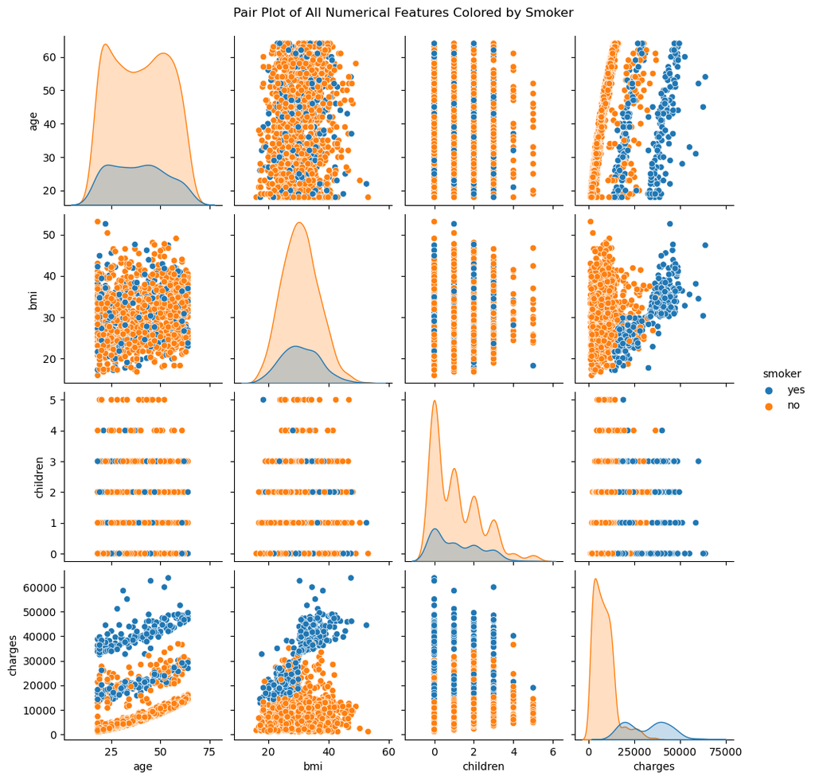

```python
sns.pairplot(df, hue='smoker')
plt.suptitle('Pair Plot of All Numerical Features Colored by Smoker', y=1.02)
plt.show()
```

#### Box Plot of Charges by Sex

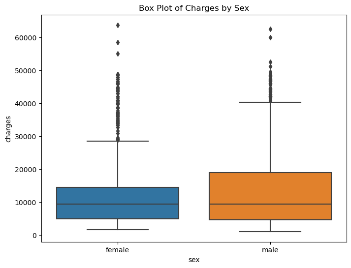

```python
plt.figure(figsize=(8, 6))
sns.boxplot(x='sex', y='charges', data=df)
plt.title('Box Plot of Charges by Sex')
plt.show()
```

#### Box Plot of Charges by Smoker Status

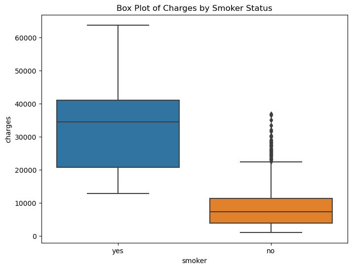

```python
plt.figure(figsize=(8, 6))
sns.boxplot(x='smoker', y='charges', data=df)
plt.title('Box Plot of Charges by Smoker Status')
plt.show()
```

##### Scatter Plot of BMI vs. Charges

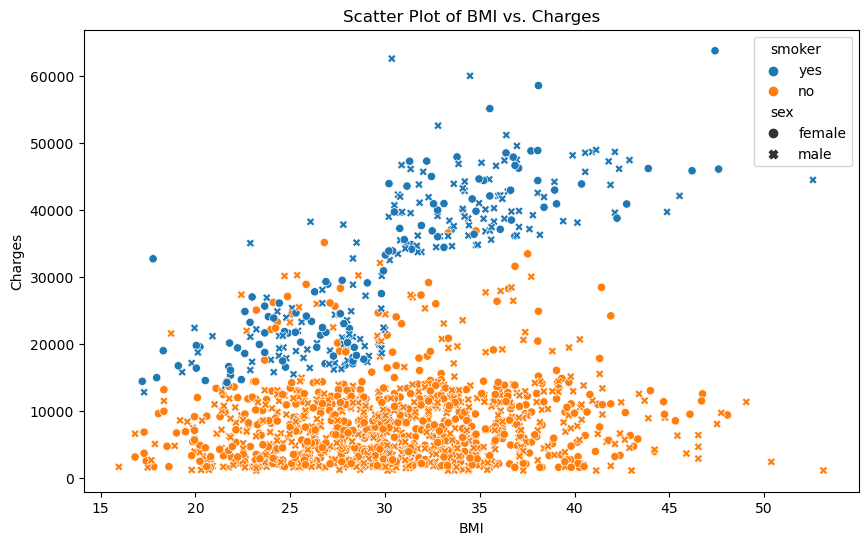

```python
plt.figure(figsize=(10, 6))
sns.scatterplot(x='bmi', y='charges', hue='smoker', style='sex', data=df)
plt.title('Scatter Plot of BMI vs. Charges')
plt.xlabel('BMI')
plt.ylabel('Charges')
plt.show()
```

## 6. Check if the number of premium charges for smokers or non-smokers is increasing as they are aging

#### Line Plot: Average charges by age for smokers and non-smokers

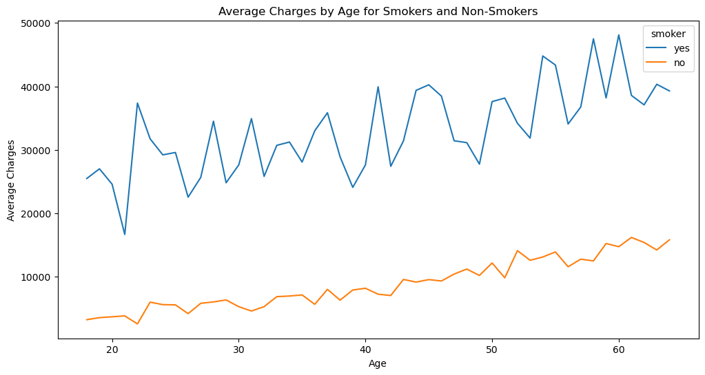

```python
plt.figure(figsize=(12, 6))
sns.lineplot(x='age', y='charges', hue='smoker', data=df, ci=None)
plt.title('Average Charges by Age for Smokers and Non-Smokers')
plt.xlabel('Age')
plt.ylabel('Average Charges')
plt.show()
```

##### Scatter Plot: Charges by age for smokers and non-smokers

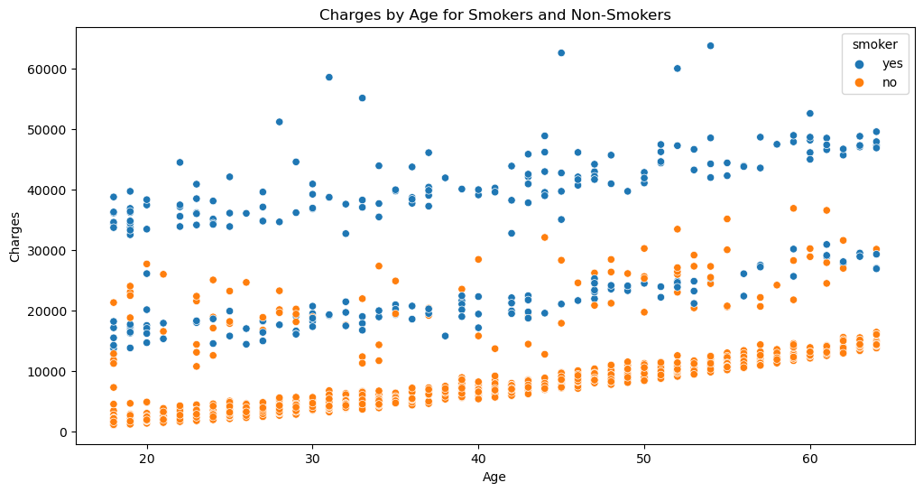

```python
plt.figure(figsize=(12, 6))
sns.scatterplot(x='age', y='charges', hue='smoker', data=df)
plt.title('Charges by Age for Smokers and Non-Smokers')
plt.xlabel('Age')
plt.ylabel('Charges')
plt.show()
```

#### Observation:

- The line plot shows that average charges tend to increase with age for both smokers and non-smokers, but charges for smokers are consistently higher.
- The scatter plot illustrates that individual charges generally increase with age, with smokers having higher charges compared to non-smokers.

## Contact Information

### For any queries or further information, please feel free to reach out to me through the following platforms:

- **LinkedIn**: [Vinay Kumar Panika](https://www.linkedin.com/in/vinaykumarpanika)
- **GitHub**: Vinaypanika